# Trade Networks: Metrics and Null Models

Irene Iodice

## Class Overview

Welcome to today’s session: **Trade Networks – Metrics and Null Models**

In this class, we’ll explore how to represent and analyze international trade as a **network**, using real trade data from CEPII’s BACI dataset. We’ll work through the following steps:

1. **Data Preparation** – Load and clean BACI trade data for 2017.
2. **Building the Trade Network** – Construct a directed network where nodes are countries and edges represent trade relationships.
3. **Visualizing the Network** – Examine the global trade structure: identify hubs, assess sparsity, and connectivity.
4. **Network Metrics** – Compute and interpret centrality measures:
   - **Degree centrality**: number of trade partners
   - **Closeness centrality**: distance to other countries in the network
   - **Betweenness centrality**: intermediary or broker roles
5. **Weighted Network Analysis** – Build a weighted network using trade values and reassess centrality.
6. **Null Model Comparison** – Compare the observed network to random graphs (Erdős–Rényi) to understand structural significance.

### Key Questions

- What makes a country central in global trade?
- How do different metrics reflect economic influence?
- What distinguishes the real trade network from a random one?

You can download the complete data at [this link here](https://www.cepii.fr/CEPII/en/bdd_modele/bdd_modele_item.asp?id=37).

## Load and Clean BACI Data

```r
data_path <- "~/work/Teaching/data-science-for-economists/05-networks/data/"

file1 <- "BACI_HS07_Y2017_V202001_p1.csv.gz"
file2 <- "BACI_HS07_Y2017_V202001_p2.csv.gz"

conversion <- fread(paste0(data_path, "country_codes_cepii_V2021.csv.gz"))[, .(isocode3 = iso_3digit_alpha, country_code)]

data_baci <- rbind(fread(paste0(data_path, file1)), fread(paste0(data_path, file2)))
data_baci <- data_baci[!grepl("^98", k) & !grepl("^99", k), .(t, i, j, k, v)]

data_baci <- data_baci[conversion, on = .(i = country_code), nomatch = 0][conversion, on = .(j = country_code), nomatch = 0]
setnames(data_baci, old = c("isocode3", "i.isocode3"), new = c("exp", "imp"))

data_baci[, c("i", "j") := NULL]
setnames(data_baci, old = c("t", "k", "v", "exp", "imp"), new = c("year", "product_code", "trade_value", "exp", "imp"))

data_baci <- data_baci[trade_value > 100]

head(data_baci)
```

```
##     year product_code trade_value    exp    imp
##    <int>        <int>       <num> <char> <char>
## 1:  2017        40310     900.577    AZE    AFG
## 2:  2017        40390     440.627    AZE    AFG
## 3:  2017        40700     227.187    AZE    AFG
## 4:  2017       271000   48652.950    AZE    AFG
## 5:  2017       271113    1875.857    AZE    AFG
## 6:  2017        20712    1569.087    ARG    AFG
```

## 2. Build the Trade Network (Unweighted)

```r
# Directed trade graph (no weights)
trade_network <- data_baci %>%
  select(exp, imp) %>%
  distinct() %>%
  graph_from_data_frame(directed = TRUE)
```

**Questions:** - What kind of relationships do nodes and edges represent in this graph? - Why should this network be directed?

## 3. Visualize the Network

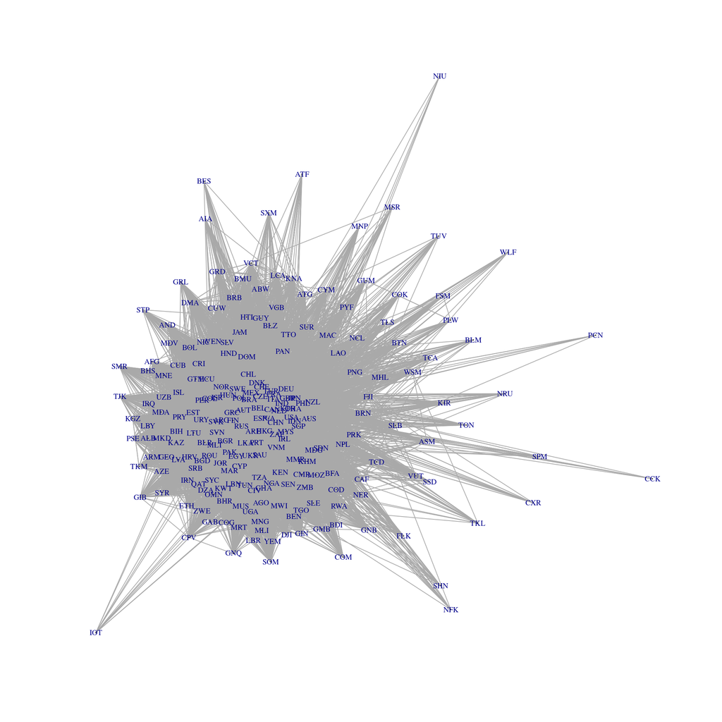

```r
trade_network <- graph_from_data_frame(d = unique(data_baci[, .(exp, imp)]), directed = TRUE)

plot(trade_network, vertex.size=0.01, vertex.label.cex=0.7, edge.arrow.size=0.1)
```

**Questions:** - Can you visually identify any hubs? - Is the network sparse or dense?

## 4. Compute Degree Centrality

```r
deg_in <- degree(trade_network, mode = "in")
deg_out <- degree(trade_network, mode = "out")

deg_in_df <- data.frame(country = names(deg_in), degree_in = deg_in)
deg_out_df <- data.frame(country = names(deg_out), degree_out = deg_out)

head(arrange(deg_in_df, -degree_in))  # Top importers
```

```
##     country degree_in
## USA     USA       204
## FRA     FRA       201
## DEU     DEU       188
## ESP     ESP       187
## NLD     NLD       185
## KOR     KOR       184
```

```r
head(arrange(deg_out_df, -degree_out))  # Top exporters
```

```
##     country degree_out
## NLD     NLD        206
## USA     USA        206
## FRA     FRA        204
## GBR     GBR        204
## DEU     DEU        202
## ITA     ITA        202
```

**Questions:** - Who are the top exporters and importers by number of trade partners? - Do these match your expectations?

## 5. Plot Degree Distribution

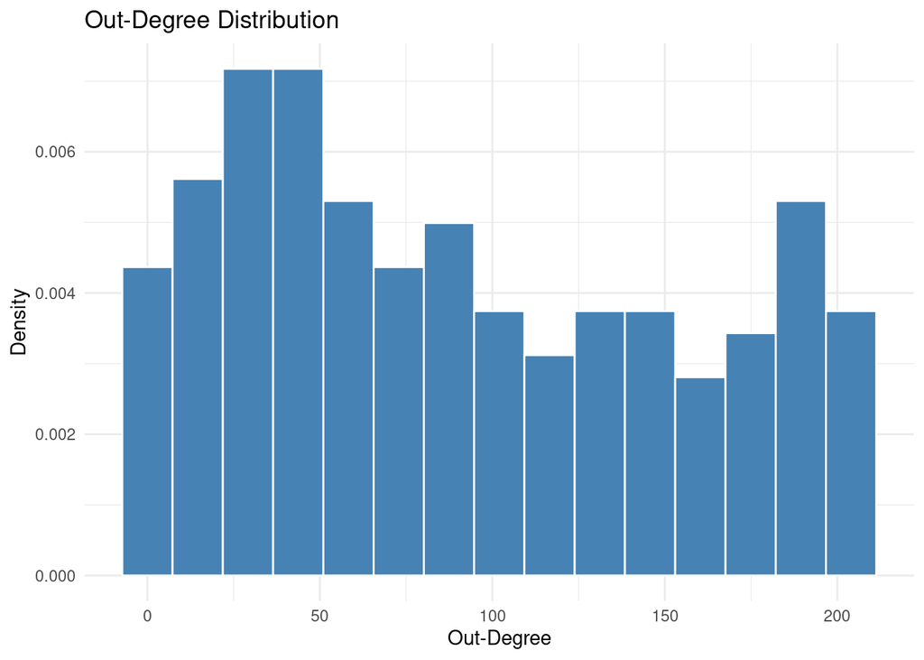

```r
ggplot(deg_out_df, aes(x = degree_out)) +
  geom_histogram(aes(y = after_stat(density)), bins = 15, fill = "steelblue", color = "white") +
  labs(title = "Out-Degree Distribution", x = "Out-Degree", y = "Density") +
  theme_minimal()
```

**Questions:** - What is the shape of the distribution? Is it skewed? - Are most countries trading with many or few partners?

## 6. Closeness Centrality

```r
closeness_in <- data.frame(
  country = names(closeness(trade_network, mode = "in")),
  centrality_in = closeness(trade_network, mode = "in")
)

closeness_out <- data.frame(
  country = names(closeness(trade_network, mode = "out")),
  centrality_out = closeness(trade_network, mode = "out")
)

head(arrange(closeness_in, -centrality_in))
```

```
##     country centrality_in
## USA     USA   0.004273504
## FRA     FRA   0.004219409
## DEU     DEU   0.004000000
## ESP     ESP   0.003984064
## NLD     NLD   0.003952569
## KOR     KOR   0.003937008
```

```r
head(arrange(closeness_out, -centrality_out))
```

```
##     country centrality_out
## NLD     NLD    0.004310345
## USA     USA    0.004310345
## FRA     FRA    0.004273504
## GBR     GBR    0.004273504
## DEU     DEU    0.004237288
## ITA     ITA    0.004237288
```

**Questions:** - Who are the most “accessible” importers and exporters? - What does it mean to have high closeness but low degree?

## 7. Betweenness Centrality

```r
btw_df <- data.frame(
  country = names(betweenness(trade_network, normalized = TRUE)),
  centrality = betweenness(trade_network, normalized = TRUE)
)

head(arrange(btw_df, -centrality))
```

```
##     country centrality
## USA     USA 0.02978434
## FRA     FRA 0.02814276
## GBR     GBR 0.02102723
## NLD     NLD 0.02048714
## SGP     SGP 0.01875931
## AUS     AUS 0.01704929
```

**Questions:** - Who plays a broker or intermediary role in the trade network? - Are there countries with **high betweenness but low degree**?

## 8. Count Nodes, Edges, and Compute Density

```r
n_nodes <- gorder(trade_network)
n_edges <- gsize(trade_network)
density <- edge_density(trade_network, loops = FALSE)

n_nodes
```

```
## [1] 220
```

```r
n_edges
```

```
## [1] 20073
```

```r
density
```

```
## [1] 0.4166252
```

**Questions:** - What is the density of the trade network? - What does this tell us about global trade interdependence?

### Create a Weighted Trade Network

```r
# Group trade flows by exporter-importer pair and sum their trade values
weighted_edges <- data_baci %>%
  group_by(exp, imp) %>%
  summarise(weight = sum(trade_value, na.rm = TRUE), .groups = "drop") %>%
  na.omit()

# Create a directed graph with edge weights
w_trade_network <- graph_from_data_frame(weighted_edges, directed = TRUE)
```

**Questions:** - What does assigning **weights** to edges mean in the context of trade? - How does weighting change the role of countries that have **few but large** trade partners? - Are “influential” countries by volume the same as those by number of partners?

```r
# Compute weighted in-degree centrality (i.e., total import value)
weighted_in_degree <- data.frame(
  country = names(strength(w_trade_network, mode = "in", weights = E(w_trade_network)$weight)),
  in_strength = strength(w_trade_network, mode = "in", weights = E(w_trade_network)$weight)
) %>%
  arrange(desc(in_strength))

# Show top 6 countries by import strength
head(weighted_in_degree)
```

```
##     country in_strength
## USA     USA  2226234312
## CHN     CHN  1471794962
## DEU     DEU  1080791857
## GBR     GBR   636823754
## JPN     JPN   632906581
## FRA     FRA   602214407
```

```r
# Weighted closeness OUT: countries that can quickly reach others by trade volume
# Compute weighted out-degree centrality (i.e., total export value)
weighted_out_degree <- data.frame(
  country = names(strength(w_trade_network, mode = "out", weights = E(w_trade_network)$weight)),
  out_strength = strength(w_trade_network, mode = "out", weights = E(w_trade_network)$weight)
) %>%
  arrange(desc(out_strength))

# Show top 6 countries by export strength
head(weighted_out_degree)
```

```
##     country out_strength
## CHN     CHN   2447309155
## DEU     DEU   1362251150
## USA     USA   1358837521
## JPN     JPN    725355977
## KOR     KOR    597961484
## FRA     FRA    531962067
```

**Questions:** - Who are the most central **importers** by weighted degree centrality? Why might they be important? - Who are the most central **exporters** by weighted degree centrality? How do they compare to the unweighted results? - Are small, highly connected economies still central when we account for trade volume? - What kind of country has high **unweighted** closeness but low **weighted** closeness—and vice versa?

**Interpretation:**  
Why might a country have high degree but low closeness in the weighted network?

## Null Model: Erdős-Rényi

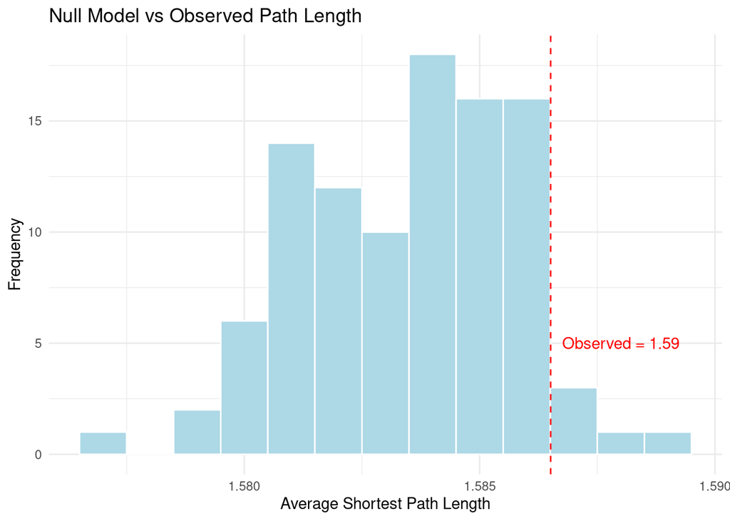

```r
set.seed(1234)
# Compute observed mean path length
obs_path_length <- mean_distance(trade_network, directed = TRUE)

# Simulate 100 Erdős-Rényi null graphs with same size and density
null_path_lengths <- replicate(100, {
  g_null <- sample_gnp(n = gorder(trade_network),
                       p = edge_density(trade_network),
                       directed = TRUE)
  mean_distance(g_null, directed = TRUE)
})

# Compute p-value
p_val <- mean(null_path_lengths <= obs_path_length)

# Plot the null distribution with observed value
null_df <- data.frame(path_length = null_path_lengths)

ggplot(null_df, aes(x = path_length)) +
  geom_histogram(binwidth = 0.001, fill = "lightblue", color = "white") +
  geom_vline(xintercept = obs_path_length, color = "red", linetype = "dashed") +
  annotate("text", x = obs_path_length, y = 5, label = paste("Observed =", round(obs_path_length, 2)), hjust = -0.1, color = "red") +
  ggtitle("Null Model vs Observed Path Length") +
  xlab("Average Shortest Path Length") +
  ylab("Frequency") +
  theme_minimal()
```

```r
# Display p-value
p_val
```

```
## [1] 0.95
```

**Interpretation:**  
What a longer than expected Average Short Path means?